# Analysis of Clinical Data for Acromegaly Patients

This file was last compiled on `Wed Apr 23 19:25:23 2014`. Unless otherwise noted this analysis removes subject 29.

## Statistics

This analysis included 11 controls and 9 acromegaly patients.

First we checked whether the data was normally distributed using a Shapiro-Wilk test. If a Shapiro-Wilk Normality test had a p-value <0.05 for a measurement in either the control or the acromegaly cases, we did a Wilcoxon test. This was appropriate for Cer.C14, Cer.C16, Cer.C20, Glu.Cer.C16, insulin, HOMA.IR, glycerol.ins.iso.iso.

We next tested, for the normally distributed data, whether the data had unequal variance. This was done using Levene's test in the car package [Fox & Weisberg (2011)](http://socserv.socsci.mcmaster.ca/jfox/Books/Companion). A Welch's t-test for unequal variance was appropriate for glycerol.no.tx based on p<0.05. In all other cases, a t-test, presuming equal variance was used.

Summary of statistical tests used

|  | shapiro.control | shapiro.acromegaly | levene.test | test |
| --- | --- | --- | --- | --- |
| height | 0.148 | 0.530 | 0.436 | Student’s T-Test |
| weight | 0.261 | 0.250 | 0.392 | Student’s T-Test |
| BMI | 0.556 | 0.157 | 0.786 | Student’s T-Test |
| abdominal.circumference | 0.690 | 0.819 | 0.581 | Student’s T-Test |
| Cer.C14 | 0.021 | 0.550 | 0.320 | Wilcoxon Test |
| Cer.C18.1 | 0.891 | 0.083 | 0.607 | Student’s T-Test |
| Cer.C16 | 0.883 | 0.001 | 0.127 | Wilcoxon Test |
| Cer.C18 | 0.916 | 0.510 | 0.083 | Student’s T-Test |
| Cer.C20 | 0.001 | 0.618 | 0.974 | Wilcoxon Test |
| Cer.C22..area. | 0.657 | 0.155 | 0.357 | Student’s T-Test |
| Cer.C24.1..area. | 0.119 | 0.209 | 0.693 | Student’s T-Test |
| Cer.C24 | 0.752 | 0.685 | 0.540 | Student’s T-Test |
| Glu.Cer.C16 | 0.674 | 0.000 | 0.770 | Wilcoxon Test |
| Glu.Cer.C18 | 0.570 | 0.104 | 0.333 | Student’s T-Test |
| Glu.Cer.C18.1 | 0.204 | 0.602 | 0.843 | Student’s T-Test |
| insulin | 0.085 | 0.004 | 0.094 | Wilcoxon Test |
| glucose | 0.458 | 0.764 | 0.078 | Student’s T-Test |
| HOMA.IR | 0.028 | 0.001 | 0.113 | Wilcoxon Test |
| glycerol.no.tx | 0.297 | 0.324 | 0.004 | Welch’s T-Test |
| glycerol.insulin.2.nM | 0.183 | 0.972 | 0.124 | Student’s T-Test |
| glycerol.iso.30.nM | 0.245 | 0.401 | 0.066 | Student’s T-Test |
| glycerol.ins.iso | 0.104 | 0.052 | 0.189 | Student’s T-Test |
| glycerol.ins.ctrl | 0.065 | 0.457 | 0.182 | Student’s T-Test |
| glycerol.iso.ctrl | 0.513 | 0.132 | 0.194 | Student’s T-Test |
| glycerol.ins.iso.iso | 0.966 | 0.001 | 0.268 | Wilcoxon Test |
| age | 0.459 | 0.242 | 0.105 | Student’s T-Test |
| largest.diameter.of.tumor | 0.784 | 0.081 | 0.414 | Student’s T-Test |
| Creatinine | 0.498 | 0.714 | 0.959 | Student’s T-Test |
| AST | 0.068 | 0.052 | 0.573 | Student’s T-Test |
| ALT | 0.231 | 0.493 | 0.562 | Student’s T-Test |
| alk.phos | 0.566 | 0.088 | 0.216 | Student’s T-Test |

|  | measurement | Control_mean | Control_se | Acromegaly_mean | Acromegaly_se | pval | padj |
| --- | --- | --- | --- | --- | --- | --- | --- |
| 28 | HOMA.IR | 2.0 | 0.3 | 7.6 | 3.1 | 0.00137 | 0.04251 |
| 2 | age | 63.4 | 2.7 | 48.3 | 4.9 | 0.01072 | 0.10354 |
| 29 | insulin | 8.7 | 0.9 | 25.7 | 8.7 | 0.01276 | 0.10354 |
| 19 | glucose | 92.5 | 2.0 | 107.0 | 5.4 | 0.01336 | 0.10354 |
| 3 | alk.phos | 68.3 | 5.5 | 95.8 | 9.4 | 0.01949 | 0.12083 |
| 27 | height | 170.0 | 2.4 | 180.1 | 4.0 | 0.03625 | 0.14779 |
| 23 | glycerol.insulin.2.nM | 5.7 | 1.2 | 11.5 | 2.5 | 0.03738 | 0.14779 |
| 13 | Cer.C24 | 4.3 | 0.6 | 6.7 | 1.0 | 0.03814 | 0.14779 |
| 21 | glycerol.ins.iso | 6.8 | 1.5 | 17.9 | 6.2 | 0.05554 | 0.18123 |
| 24 | glycerol.iso.30.nM | 7.6 | 1.6 | 20.7 | 7.5 | 0.05846 | 0.18123 |
| 8 | Cer.C16 | 3.4 | 0.4 | 4.4 | 0.3 | 0.06926 | 0.19518 |
| 7 | Cer.C14 | 0.3 | 0.0 | 0.3 | 0.0 | 0.08534 | 0.22047 |
| 26 | glycerol.no.tx | 4.9 | 0.8 | 13.1 | 4.2 | 0.10735 | 0.25599 |
| 31 | weight | 89.4 | 6.7 | 103.9 | 9.3 | 0.21028 | 0.43588 |
| 16 | Glu.Cer.C16 | 0.3 | 0.0 | 0.3 | 0.1 | 0.21091 | 0.43588 |
| 15 | Creatinine | 0.9 | 0.1 | 0.8 | 0.1 | 0.23710 | 0.45937 |
| 18 | Glu.Cer.C18.1 | 0.2 | 0.0 | 0.2 | 0.0 | 0.32498 | 0.59260 |
| 30 | largest.diameter.of.tumor | 2.0 | 0.2 | 1.7 | 0.3 | 0.36331 | 0.62571 |
| 12 | Cer.C22..area. | 7164.8 | 1260.3 | 9530.4 | 3147.3 | 0.43251 | 0.70568 |
| 10 | Cer.C18.1 | 0.7 | 0.0 | 0.7 | 0.0 | 0.51421 | 0.79703 |
| 1 | abdominal.circumference | 100.7 | 4.6 | 104.9 | 6.3 | 0.58776 | 0.81898 |
| 5 | AST | 23.5 | 1.5 | 22.1 | 2.5 | 0.61192 | 0.81898 |
| 20 | glycerol.ins.ctrl | 1.1 | 0.1 | 1.1 | 0.1 | 0.61304 | 0.81898 |
| 4 | ALT | 23.5 | 2.0 | 25.2 | 2.9 | 0.63405 | 0.81898 |
| 6 | BMI | 30.7 | 1.8 | 31.7 | 2.1 | 0.69818 | 0.86574 |
| 25 | glycerol.iso.ctrl | 1.5 | 0.1 | 1.6 | 0.5 | 0.78890 | 0.94061 |
| 9 | Cer.C18 | 0.4 | 0.0 | 0.4 | 0.0 | 0.83600 | 0.95985 |
| 14 | Cer.C24.1..area. | 7723.5 | 2072.9 | 7319.0 | 2454.8 | 0.90271 | 0.98238 |
| 17 | Glu.Cer.C18 | 0.4 | 0.0 | 0.4 | 0.0 | 0.91900 | 0.98238 |
| 11 | Cer.C20 | 0.6 | 0.0 | 0.6 | 0.0 | 1.00000 | 1.00000 |
| 22 | glycerol.ins.iso.iso | 0.9 | 0.1 | 1.5 | 0.6 | 1.00000 | 1.00000 |

## Barplots

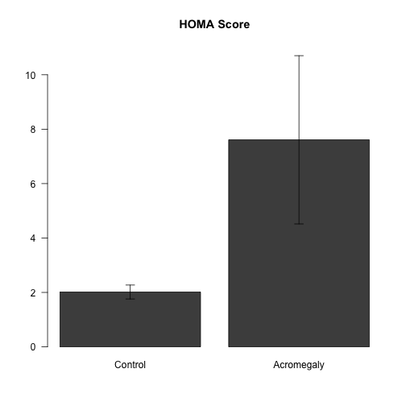

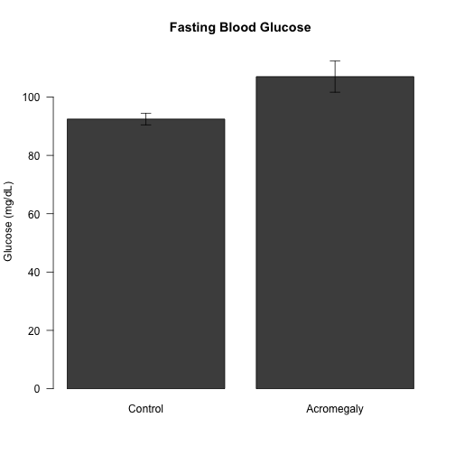

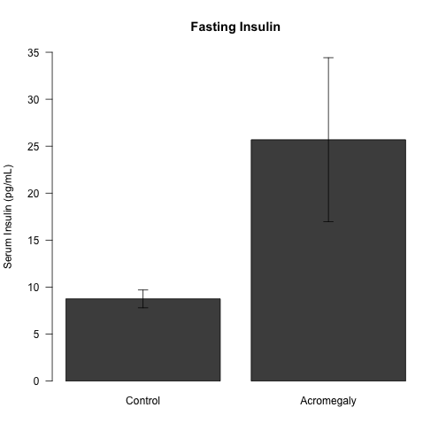

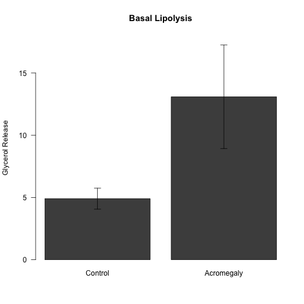

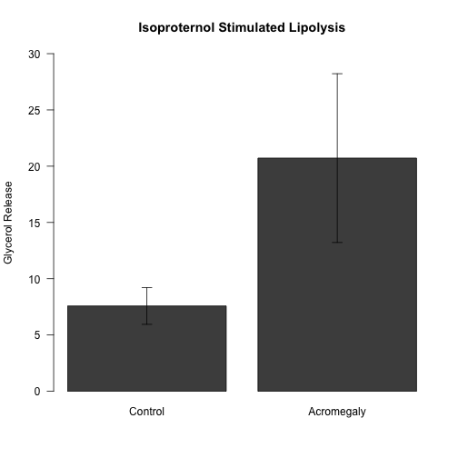

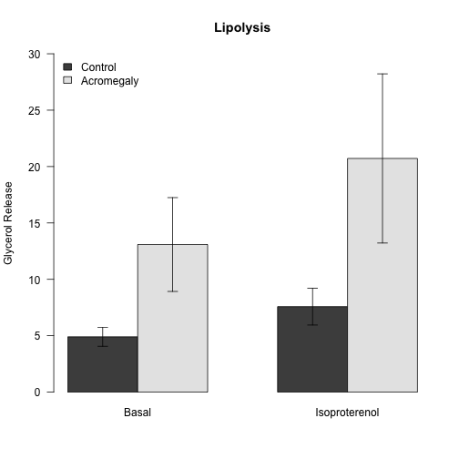

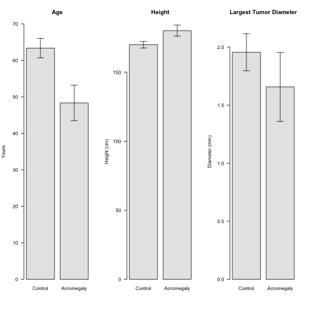

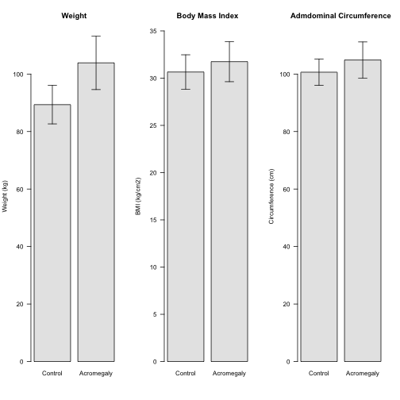

## Correlation with BMI

|  | Estimate | Std. Error | t value | Pr(>\|t\|) |
| --- | --- | --- | --- | --- |
| (Intercept) | -1.2268 | 0.6719 | -1.83 | 0.0879 |
| BMI | 0.0602 | 0.0210 | 2.86 | 0.0118 |
| diagnosisAcromegaly | 0.9085 | 0.2529 | 3.59 | 0.0027 |

|  | 2.5 % | 97.5 % |
| --- | --- | --- |
| (Intercept) | 0.07 | 1.23 |
| BMI | 1.02 | 1.11 |
| diagnosisAcromegaly | 1.45 | 4.25 |

The results of this linear model are a significant main effect of both BMI (p=0.0118) and the diagnosis (p=0.0027) with a r-squared value of 0.5667. This corresponds to an effect size of 2.4807.

### Model Plot

```r
pdf("../figures/Acromegaly - BMI-HOMA Correlation.pdf")
with(acromegaly.data, plot(BMI, log(HOMA.IR), pch = 19, las = 1, col = diagnosis,
    ylab = "Log HOMA-IR Score", xlab = "BMI (mg/kg2)"))
legend("topleft", levels(acromegaly.data$diagnosis)[1:2], pch = 19, bty = "n",
    col = palette()[1:2], lty = 1)
with(acromegaly.data[acromegaly.data$diagnosis == "Control" & acromegaly.data$id !=
    "29", ], abline(lm(log(HOMA.IR) ~ BMI), col = palette()[1]))
with(acromegaly.data[acromegaly.data$diagnosis == "Acromegaly" & acromegaly.data$id !=
    "29", ], abline(lm(log(HOMA.IR) ~ BMI), col = palette()[2]))
dev.off()
```

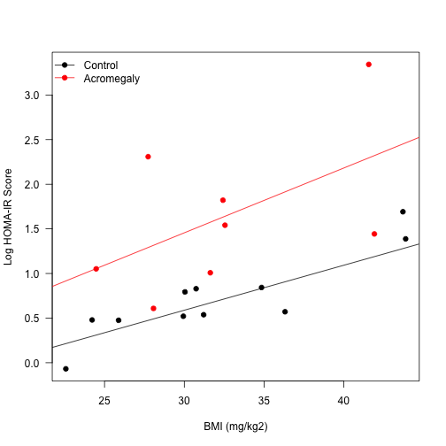

```r
with(acromegaly.data, plot(BMI, log(HOMA.IR), pch = 19, las = 1, col = diagnosis,
    ylab = "Log HOMA-IR Score", xlab = "BMI (mg/kg2)"))
legend("topleft", levels(acromegaly.data$diagnosis)[1:2], pch = 19, bty = "n",
    col = palette()[1:2], lty = 1)
with(acromegaly.data[acromegaly.data$diagnosis == "Control" & acromegaly.data$id !=
    "29", ], abline(lm(log(HOMA.IR) ~ BMI), col = palette()[1]))
with(acromegaly.data[acromegaly.data$diagnosis == "Acromegaly" & acromegaly.data$id !=
    "29", ], abline(lm(log(HOMA.IR) ~ BMI), col = palette()[2]))
```

### Model Diagnostics

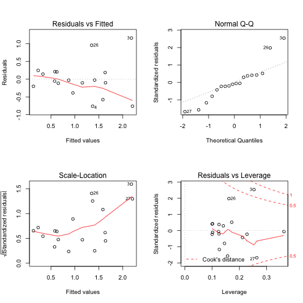

## Separation out of Outlier Data

[output not shown]

[output not shown]

[output not shown]

[output not shown]

## Ceramides

We tested whether ceramides were elevated in acromegaly patients.

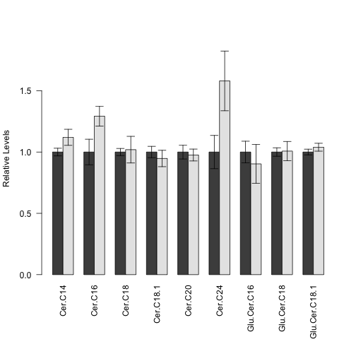

|  | measurement | Control_mean | Control_se | Acromegaly_mean | Acromegaly_se | pval | padj |
| --- | --- | --- | --- | --- | --- | --- | --- |
| 13 | Cer.C24 | 4.3 | 0.6 | 6.7 | 1.0 | 0.03814 | 0.25603 |
| 8 | Cer.C16 | 3.4 | 0.4 | 4.4 | 0.3 | 0.06926 | 0.25603 |
| 7 | Cer.C14 | 0.3 | 0.0 | 0.3 | 0.0 | 0.08534 | 0.25603 |
| 16 | Glu.Cer.C16 | 0.3 | 0.0 | 0.3 | 0.1 | 0.21091 | 0.47455 |
| 18 | Glu.Cer.C18.1 | 0.2 | 0.0 | 0.2 | 0.0 | 0.32498 | 0.58496 |
| 10 | Cer.C18.1 | 0.7 | 0.0 | 0.7 | 0.0 | 0.51421 | 0.77132 |
| 9 | Cer.C18 | 0.4 | 0.0 | 0.4 | 0.0 | 0.83600 | 1.00000 |
| 17 | Glu.Cer.C18 | 0.4 | 0.0 | 0.4 | 0.0 | 0.91900 | 1.00000 |
| 11 | Cer.C20 | 0.6 | 0.0 | 0.6 | 0.0 | 1.00000 | 1.00000 |

## References

- John Fox, Sanford Weisberg, (2011) An {R} Companion to Applied Regression. http://socserv.socsci.mcmaster.ca/jfox/Books/Companion